# QTM 151 - Quiz 4

## Try to submit as an HTML file

Print your name below

```python
# Write your answer here

print("Lydia")
```

```
Lydia
```

This quiz is open book

- You can use the lecture notes
- You will get partial credit for attempting the questions
- To get full credit, the code should run as intended
- You should NOT communicate with other students

Print the following message:

"I will abide by Emory's code of conduct"

```python
# Write your answer here:
print("I will abide by Emory's code of conduct")
```

```
I will abide by Emory's code of conduct
```

Import the libraries "matplotlib.pyplot" and "pandas"

```python
# Write your answer here
import matplotlib.pyplot as plt
import pandas as pd
```

In this quiz you will work with data on exchange rates,  
for the following currencies:

- 1 euro (EUR) to dollar (USD)
- 1 pound (GPB) to dollar (USD).

(a) Import and parse dates

- Import the dataset "currencies.csv"
- Parse the "date_string" column with `pd.to_datetime()`
- To get full points, set the "format" option using wildcards as in Lecture 16.

```python
# Write your own code

currencies = pd.read_csv("/Users/lydiaking/Documents/GitHub/qtm151spring2025/Quiz4/data_raw/currencies.csv")
currencies['date'] = pd.to_datetime(currencies["date_string"], format = "%A, %b %d, %Y")
```

(b) Plot multiple time series

- Create a line plot plot which has the "gbp_to_usd" and "eur_to_usd" on the y-axis  
  and the date on the x-axis
- Label the x-axis, the y-axis, and the title
- Add a legend and set the names to "1 Euro to USD" and "1 GPB to USD"

Hint: See Lecture 18 for how to plot multiple columns  
Hint: Remember to include the legend names as a list `[...]`

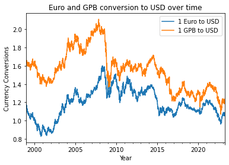

```python
# Write your own code

currencies[["date", "gbp_to_usd", "eur_to_usd"]].set_index("date").plot()
plt.xlabel("Year")
plt.ylabel("Currency Conversions")
plt.legend(["1 Euro to USD", "1 GPB to USD"])
plt.title("Euro and GPB conversion to USD over time")
plt.show()
```

(c) Compute growth rates

- Calculate a new column "growth_euro" which computes the percentage daily  
  growth rate of "eur_to_usd".

Hint: Use `.diff()` and `.shift(1)`

```python
# Write your own code
currencies["diff_eur_to_usd"] = currencies["eur_to_usd"].diff()
currencies["lag_eur_to_usd"] = currencies["eur_to_usd"].shift(1)
currencies["growth_euro"] = (currencies["diff_eur_to_usd"] / currencies["lag_eur_to_usd"]) * 100
```

(d) Flag subset of data and plot

- Create a boolean colum (True/False) "bool_cond" which checks whether  
  "growth_euro" had a value greater than 2 or less than -2
- Generate a line plot with the "growth_euro" series, label the axes and the title
- Use the command `plt.fill_between()` as in Lecture 18 to create a shaded region  
  for time periods where "bool_cond" is true.

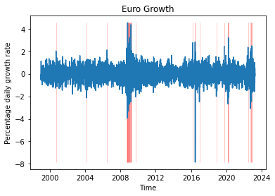

```python
# Write your own code



currencies["bool_cond"] = (currencies["growth_euro"] > 2) | (currencies["growth_euro"] < -2)


plt.plot("date", "growth_euro", data=currencies)
plt.fill_between(x=currencies["date"],
                 y1=currencies["growth_euro"].min(),
                 y2=currencies["growth_euro"].max(),
                 where=currencies["bool_cond"],
                 alpha=0.2, color="red")
plt.title("Euro Growth")
plt.xlabel("Time")
plt.ylabel("Percentage daily growth rate")
plt.show()
```

(e) Aggregate dataset by time period

- Create an object "month_config" that uses `pd.Grouper()`, setting the key to  
  the column "date" and freq to "m" (month)
- Follow the instructions in Lecture 16 to compute an aggregate dataset  
  by month which computes the standard deviation of "eur_to_usd"
- Display the dataset

```python
# Write your own code

month_config = pd.Grouper(key='date', freq='m')

monthlydata = (currencies
               .groupby(month_config)
               .agg(eur_std = ("eur_to_usd","std"))
               .reset_index())

display(monthlydata)
```

|  | date | eur_std |
| --- | --- | --- |
| 0 | 1999-01-31 | 0.007345 |
| 1 | 1999-02-28 | 0.013345 |
| 2 | 1999-03-31 | 0.010475 |
| 3 | 1999-04-30 | 0.006172 |
| 4 | 1999-05-31 | 0.013046 |
| ... | ... | ... |
| 286 | 2022-11-30 | 0.027308 |
| 287 | 2022-12-31 | 0.011389 |
| 288 | 2023-01-31 | 0.015046 |
| 289 | 2023-02-28 | 0.008972 |
| 290 | 2023-03-31 | 0.016246 |

291 rows × 2 columns

(f) Convert a dataset to long format

- Convert the currencies dataset to long format using the following inputs

```
var_name   = "type",
value_name = "exchange_rate",
id_vars    = "date",
value_vars = ["eur_to_usd","gbp_to_usd"]
```

- Display the dataset

Hint: See Lecture 18 for details on `pd.melt()`

```python
# Write your own code

currencies_long = pd.melt(currencies,
                         var_name="type",
                         value_name="exchange_rate",
                         id_vars="date",
                         value_vars=["eur_to_usd", "gbp_to_usd"])

display(currencies_long)
```

|  | date | type | exchange_rate |
| --- | --- | --- | --- |
| 0 | 1999-01-04 | eur_to_usd | 1.6581 |
| 1 | 1999-01-05 | eur_to_usd | 1.6566 |
| 2 | 1999-01-06 | eur_to_usd | 1.6547 |
| 3 | 1999-01-07 | eur_to_usd | 1.6495 |
| 4 | 1999-01-08 | eur_to_usd | 1.6405 |
| ... | ... | ... | ... |
| 12645 | 2023-03-27 | gbp_to_usd | 1.0789 |
| 12646 | 2023-03-28 | gbp_to_usd | 1.0844 |
| 12647 | 2023-03-29 | gbp_to_usd | 1.0826 |
| 12648 | 2023-03-30 | gbp_to_usd | 1.0899 |
| 12649 | 2023-03-31 | gbp_to_usd | 1.0872 |

12650 rows × 3 columns